# Updated meta-analysis of environmental Kuznets curve: Where do we stand? - ScienceDirect

## Figures (5)

[figure not shown]

[figure not shown]

[figure not shown]

[figure not shown]

[figure not shown]

## Tables (4)

1. Table 1
2. Table 2
3. Table 3
4. Table 4

## Extras (1)

1. Supplementary material

## [Environmental Impact Assessment Review](https://www.sciencedirect.com/science/journal/01959255)

[Volume 86](https://www.sciencedirect.com/science/journal/01959255/86/supp/C), January 2021, 106503

# Updated meta-analysis of environmental Kuznets curve: Where do we stand?

[MuhammadSaqib](https://www.sciencedirect.com/science/article/pii/S0195925520307812#!)[FrançoisBenhmad](https://www.sciencedirect.com/science/article/pii/S0195925520307812#!)

https://doi.org/10.1016/j.eiar.2020.106503[Get rights and content](https://s100.copyright.com/AppDispatchServlet?publisherName=ELS&contentID=S0195925520307812&orderBeanReset=true)

## Highlights

**•**

PRIMRA provided guidelines on each step of meta-analysis.

**•**

A strong evidence for validation of EKC has been found.

**•**

EKC is irrelevant of using any data sets, econometric tools, control variables.

**•**

The results are sensitive to measurement of environmental pollution indicators.

**•**

Achievement of EKC has been found as long run phenomenon.

## Abstract

The relationship between income growth and environmental quality has been frequently investigated in the literature. These investigations are not unified on a single point and have yielded in a broad spectrum of conflicting results. Major portion of the literature argues that there exists an inverted U-shaped relationship between per capita income and environmental quality. While another stream of research opposes these findings and rejects environmental Kuznets curve (EKC). To investigate these variations, the present study synthesizes the existing findings and conducting meta regression analysis on a broad level. The contribution of this study is twofold; first, a framework, Preferred Reporting Items for Meta Regression Analysis (PRIMRA), has been developed, which is aimed to provide a pathway for future meta-analyses. This study itself has been carried out in the light of this framework. Second, this is the very first attempt to synthesize EKC literature by using quantitative methods on a broad level. Reviewing 101 research papers published during 2006–2019, we have found a strong evidence in support of EKC. It has been found that this relationship is a long run phenomenon and irrelevant to the choice of econometric tools employed or type of data used. Although the results show variations with the choice of environmental degradation indicators.

## Keywords

CO<sub>2</sub> emission

Economics growth

EKC

Meta-analysis

PRIMRA

Multinomial logistic regression

## 1. Introduction

Environmental Kuznets Curve (EKC *henceforth*) is mostly debated and frequently cited in literature for three decades. EKC explains how economic activities affect environmental quality both in the short as well as in the long run. The EKC has been originated from the seminal work of Grossman and Krueger (1991), who found an inverted U-shape relationship between SO<sub>2</sub> and income per capita. In the beginning, until an income turning point (ITP *henceforth*), economic growth may require excessive resource utilization, including energy (Pham et al., 2020), paired with deforestation (Khan et al., 2019), which causes pollution but beyond that point environmental quality improves with further increase in income (Grossman and Krueger, 1995; Selden and Song, 1994; Harbaugh et al., 2002). Hence, the relationship between environmental quality and income growth is of quadratic nature (Panayotou, 1993; Destek and Sarkodie, 2019) and can be placed in a key position for policy implications. However, this theory cannot be applied for all types of pollutants and environmental effects (Stern, 2003). On the other hand, there are also some factors like financial development, foreign direct investment (Nasir et al., 2019), population, international trade and technological development which can affect environment both in the short as well as in the long run (Pham et al., 2020).

Since its inception EKC has been an area of continuous debate specially in the recent past. Many researchers have investigated its validity for different countries and regions. Anyhow concern about its empirical validity is still ambiguous. Studies conducted have used different methodologies, data sets and environmental damage indicators and yielded in broad spectrum of conflicting results (Li et al., 2007; Ahmed and Long, 2012). Around 57% of literature confirms the empirical validity of EKC hypotheses (see for example, Dinda and Coondoo, 2006; Tamazian et al., 2009; Shahbaz et al., 2012; Tiwari et al., 2013; Farhani et al., 2014; Apergis and Ozturk, 2015; Moutinho et al., 2017; Pata, 2018; etc.) and favored EKC for environmental policy formulations. On the contrary, there are also various studies (43% literature) that found no or very weak relationship. These studies oppose EKC for any policy implications (Pao et al., 2011; Begum et al., 2015; Jebli and Youssef, 2015; Al-Mulali et al., 2016; Dogan and Turkekul, 2016; Liu et al., 2017; etc.).

The empirical literature on EKC hypotheses yields mixed results and raises controversies whether it can be used for policy implications or not? The portion of literature which validates its existence, draw inferences that society can cover most environmental problems with the income growth (Dinda and Coondoo, 2006) while studies including Selden et al. (1999); Pao et al. (2011); and Liu et al. (2017) oppose the interpretation of EKC as a substitute for environmental policy formulation. The above-mentioned controversies raise uncertainties and questions the reliability of the results. As both streams of literature use different tools and techniques, and this could be the main reason for conflicting results. Many studies which reject EKC hypotheses are based upon single country analysis (Pao et al., 2011; Begum et al., 2015; Zambrano-Monserrate et al., 2018). In the same way, results for different econometric techniques also yield different results. Thus, these critiques leave room for further verification of the existing findings on aggregate level. A detailed investigation is needed to explore that what has been achieved through the past researches and what are yet to be done.

Extending the previous works, the objective of this study is to investigate the systematic variations among existing findings. For this purpose, it is aimed to conduct meta regression analysis on a broad level. The study aims to synthesize the previous results in the literature and draw some economically meaningful inferences. This is the first comprehensive study in the domain of EKC which covers large number of published articles during 2006–2019 and adapt quantitative tools for analysis. The present study is contributing to the literature in two aspects; first, following Moher et al. (2009), the study introduces a new framework, Preferred Reporting Items for Meta Regression Analysis (PRIMRA), that is expected to help researchers in future while conducting meta-analysis and quantitative reviews. The PRIMRA framework is an extension to Preferred Reporting Items for Systematic Reviews and Meta-Analysis (PRISMA) and illustrates five simple steps about how to conduct meta-analysis. The methodology portion of this study itself has been covered by this framework. Second, in most cases the quantitative investigations are preferred over descriptive and qualitative investigations. So, this study is a quantitative examination of EKC literature which eliminates doubts over its validity. The utilization of pre-estimation econometric test to select the model and post-estimation econometric tests to validate the reliability of results will help to address the problem well. The results of this study are expected to contribute the future researches especially, not limited to, in the same domain growth and environmental economics. Academic researchers as well as policy makers can also be benefited from the findings of this study.

## 2. Meta regression analysis

Meta-analysis is a statistical approach which models the relevant empirical literature that appear as observations in the data set (Li et al., 2007). This is a formal method to amalgamate the outcomes of identical empirical studies and through light on the systematic variation in variables and results (Cavlovic et al., 2000). The main purpose of meta-analysis is to deduce meaningful inferences related to literature. While, meta-regression analysis is an extension to the meta-analysis which inquires the degree to which the statistical disparity among studies can be linked to common characteristics (Thompson and Higgins, 2002). Meta Regression analysis provides the opportunity to “analyze the analysis” instead of relying on individual studies results. Studies are objectively collected from related literature but only some response variables and summary statistics are chosen subjectively. The main advantage of this methodology is the wide coverage of analysis based upon statistical tools and hypothesis testing. Contrary, there is a little possibility of selection bias and essential fluctuations across sample studies which may not be compliant to simple categorization. Moreover, only quantitative studies can be taken into consideration rather than qualitative studies. Because qualitative studies cannot be used to fetch data from.

## 3. Preferred reporting items for meta regression analysis

Preferred reporting items for systematic reviews and meta-analysis (PRISMA) is a framework developed by Moher et al. (2009). This framework assist researchers and practitioners to yield improved and more appealing reviews. In the literature it has been frequently utilized for systematic reviews of published studies. This provides some useful steps in order to conduct quality reviews. Following Moher et al. (2009), we have developed a similar framework called Preferred Reporting Items for Meta Regression Analysis (PRIMRA) which is anticipated to facilitate the quantitative aspect of Meta-analyses. This framework is an extension to PRISMA and provides guidelines to conduct quantitative meta-analysis. PRIMRA is comprised of five steps and is aimed to assist the researchers and practitioners in conducting more comprehensive reviews of literatures. Fig. 1 illustrates the five steps of this framework in brief while each step has been discussed in detail below.

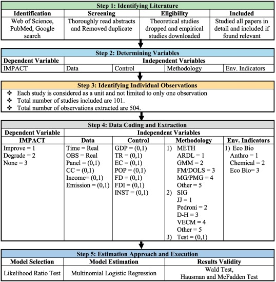

Fig. 1. Preferred Reporting Items for Meta Regression Analysis (PRIMRA).

### 3.1. Identifying literature

The first step comprises of whole PRISMA process from identification until inclusion of subjective studies. Searching for the relevant literature is considered as time consuming step of the whole process (Sebri, 2015). The EKC has been emerged for thirty years, but the frequency of publications has increased in the recent decade and specially in the past five years as indicated in Fig. 2. Further, Li et al. (2007) have examined studies from 1992 until 2005 that's why we have considered the time period onward until 2019. Following the methodology of Sarkodie and Strezov (2019), studies published in peer reviewed journals have searched through web of science, PubMed and general google search. Papers included in the study are mainly published in Elsevier, Springer, Taylor & Francis and Willey online. Sarkodie and Strezov (2019) argues to define clear keywords and timespan for searching literature. So, to search for targeted literature we have used keywords like Environmental Kuznets curve, income growth and emission, economic growth and CO<sub>2</sub> emission, economic growth and environmental quality, income turning points, EKC and turning point. In every search the time span was specified as 2006-2019

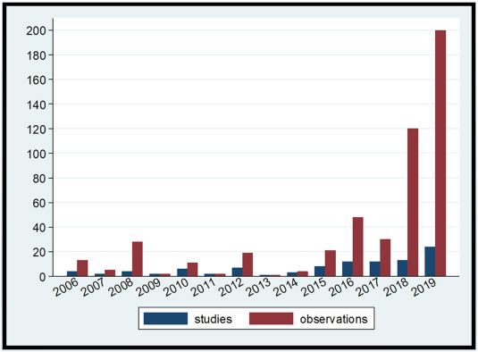

Fig. 2. Year wise distribution of studies and observations.

Initially, 213 papers from PubMed and 475 papers in web of science were found with some addition from general google search (majority of them were common). At first attempt their abstracts were reviewed and if found relevant, then downloaded and studied in detail. Only studies carried out for the empirical validation of EKC are included because theoretical studies cannot be used to extract data for different variables used in our analysis. At the end only 101 studies were left which fulfill the whole criteria we selected. The per year frequencies of studies are presented in Fig. 2. The whole sample size provides 504 observations and are explained with detail about selection criteria in section 3.3. Our study aims to provide more detailed and comprehensive data set as against those in literature (25 research papers by Cavlovic et al., 2000; 77 by Li et al., 2007 and 40 by Sebri, 2015). More than half of our data set validates EKC (see Fig. 3).

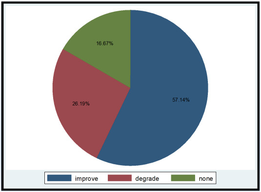

Fig. 3. Category wise distribution of all observations.

### 3.2. Determining variables

Selecting variables is in fact the most difficult task in this whole process. Utmost care was taken in selection, specifically how to measure all these, in order to formulate more convincing database. This study follows Li et al. (2007), so some variables are taken and defined in the same way. But major changes are being made specially in variables measurement and categorization. The detailed list of variables with descriptive statistics is presented in Table 1.

Table 1. Variables and descriptive statistics.

[output not shown]

Based upon the behavior of beta (β) coefficients, the income environment nexus can be grouped in seven categories: (1) Monotonic increasing, (2) Monotonic decreasing, (3) True EKC relation, (4) Inverse EKC relation, (5) Cubic relation, (6) Insignificant relationship, (7) None. Insignificant relationship means that estimated coefficients appear insignificantly with consistent signs for an EKC, while, none refers to no relationship either significant or insignificant. In a nutshell, these categories can be summarized as either improvement or worsen. Improvement refers to significant monotonic decreasing and inverted U-shaped relationship, meaning that economic growth leads to improve quality of environment. While significant monotonic increasing, U-shaped or N-shaped relationships were categorized as worsen. This means that environment will deteriorate with economic growth. All other possibilities (insignificant parameters or no relationship) are being grouped as none. Hence the dependent categorical variable is trichotomous titled as IMPACT. Fig. 3 illustrates the percentage of studies which fall in either category while Fig. 4 illustrates the yearly frequency of these categories reported from literature.

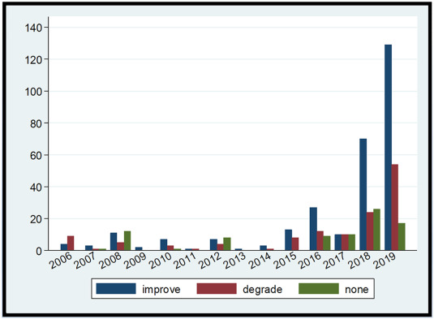

Fig. 4. Year wise distribution of categories.

The independent variables are divided in four groups: data related, controlled variables, methodology and environmental indicators. Data related group comprises of different characteristics like time period (ln*T*), number of observations (ln*OBS*), time series or panel data (PANEL), and single country or cross-country analysis (CC). Or either the study has been conducted for high income (INCOME) or lower income country/countries. And either the environmental pollution has been measured as EMISSION or anything else. Time period and number of observations are actual variables which appear in natural log form while the rest four are dummies.

Control variables are those which are being used as explanatory variables in each observation for estimation of EKC. Selection has been made based upon the most frequent variables used in the literature which play significant role in either existence or absence of EKC. It comprises of 7 variables and all appear as dummies. This category includes GDP/GDP per capita, international trade (TRADE), energy consumption (EC), population growth (POP), financial development (FD), foreign direct investment (FDI) and institutional development (INST). The variable GDP is the key variable which play important role in the existence or non-existence of EKC. Pham et al. (2020)

Methodological variables are those which explain the type of statistical or econometric tools used for estimation like; autoregressive distributed lag model (ARDL), generalized method of moments (GMM), mean group and pooled mean group (MG/PMG), dynamic and fully modified ordinary least square (DOLS/FMOLS) or any other technique (like vector autoregression, quantile regression, threshold causality etc. that appear less than 5% each in whole data set). This variable is polychotomous and has named as (METH). In the same way either any cointegration technique like Johansen or Pedroni, and causality tests like vector error correction method (VECM) or Dumitrescu and Hurlin (DH) are applied or not. At the end, if any robustness test (TEST) has been used to validate the results or not. Detailed explanation for each variable is present in corresponding sections of Table 1.

The final group comprise of indicator variables that are being used to measure environmental damage. This alternative categorization of environmental indicators helps to differentiate among different types of pollutions. For example, anthropogenic gases (ANTHRO) that are concerned with air pollution include CO<sub>2</sub>, CH<sub>4</sub>, N<sub>2</sub>O and SF<sub>6</sub>, although literature is dominated by CO<sub>2</sub>. On the other hand, the chemically active gases (CHEM) which facilitate the formation of other anthropogenic gases and water pollution by chemical interactions are SO<sub>2</sub>. While biological related indicators, hazardous waste (Industrial or agriculture) and ecological indicators have been measured separately (Bio-Eco).

### 3.3. Identifying individual observations

After variables selection, observations in each study are identified. Each study is considered as a unit and is not limited to only one observation. Efforts have been made to extract the maximum information from each study. If the study is conducted for more than one pollutant (Song et al., 2008; Farhani et al., 2014; Li et al., 2016; Armeanu et al., 2018) and results are reported separately, the results of each pollutant are taken as separate observation. In the same way, various studies are comprised of panel data and cross-country analysis (e.g. Bilgili et al., 2016; Dong et al., 2018; Sarkodie and Strezov, 2018; Işık et al., 2019; Wang et al., 2019; etc.). If any study has reported results separately for each country, then each result has been taken as an observation. Few studies also have employed different econometric methods, for robustness analysis and to check the reliability of results (Li et al., 2016; Ali et al., 2017; Acar et al., 2018; Hao et al. 2018; Pata, 2018; Lau et al., 2019). So if any study has reported results for different techniques, each result has been taken as separate observation. Fig. 4 provides a picture of whole sample size, comprised of 504 observations. The data set is more comprehensive and covers studies almost double of those in literature and is aimed to give more reliable results.

### 3.4. Data coding and extraction

Codes are being assigned to all categorical as well as dummy variables. The dependent variable (IMPACT) is trichotomous and has assigned; “1” for IMPROVE (288 observations) that includes results for significant monotonic decreasing or significant *inverted U-shape* curve. While “2” is assigned to DEGRADE (132 observations) including significant monotonic increasing, significant *U-shape* and significant *N-shape.* And “3” is assigned to NONE (84 observations) which includes all other possibilities like no linear and quadratic relationship, insignificant decreasing or insignificant *U-shape.*

In independent variables, there are only two explanatory variables in data category (ln*T* and ln*OBS*), which appear in real values form. Natural log has been taken to minimize the possible variations among observations and avoid outlier problem. While for dummy variables, “1” has been assigned if the study uses panel data (134 observations), otherwise “0” for time series data (370 observations). In the same way if the study used data for cross countries (95 observations), then “1” otherwise “0” for single country (409 observations). If the study is conducted for middle, upper middle or high-income country/countries (394 observations), then “1” otherwise “0” for lower or lower-middle income countries (110 observations). The rest of all variables in control category are assigned “1” for their presence and “0” for absence as shown in the Table 1 above.

Variables in methodology section comprise of two categorical and one dummy variable. Categorical variables for econometric methodology (METH) comprise of five categories, If the study uses ARDL, then = 1 (44 observations), If the study uses GMM, then = 2 (31 observations), If the study uses FM/DOLS, then = 3 (111 observations), If the study applies MG/PMG, then = 4 (73 observations), or If the study uses any other than above four, then = 5 (245 observations). It should be noted that all codes assigned for 1 to 5 does not mean any raking or superiority/inferiority. All observations for all categorical variables are equally treated with same weight. Categorical variable for co-integration or causality (SIG) is also comprised of five categories. If the study uses Johansen co-integration (JJ), then = 1 (13 observations), if Pedroni cointegration (Pedroni), then = 2 (56 observations), If Dumitrescu and Hurlin non-causality (D-H), then = 3 (19 observations), If VECM, then = 4 (122 observations), and if no such test has been applied (Other), then = 5 (294 observations). The only dummy variable in this category is (TEST). If any robustness test has been applied then = 1 (179 observations), otherwise = 0 for none.

Finally, for environmental damage measurement variable (INDIC) is trichotomous. If the damage has been measured as anthropogenic (ANTHRO), then = 1 (450 observations), if it has been measured as chemical gas (CHEM), then = 2 (24 observations), if it has been measured as biological related pollutant (Bio-Eco), then = 3 (30 observations). Once again it should be noted that all codes are of equal values and are treated equal in weights.

### 3.5. Estimation approach and execution

The last step is the selection of precise statistical technique for model estimation. There are various methodologies like Generalized linear model, Probit, Logit and Tobit etc. that can be applied in the presence of qualitative variables. But Long and Freese (2001) argue that in case of categorical dependent variable when the alternatives are dissimilar and not substitutes of each other, then multinomial Logistic regression (MNL) works more effectively. MNL can be used in case of more than two possible outcomes for the dependent variable with frequent dichotomous independent variables. In our case we have three categories of the dependent variable and completely dissimilar to each other. This makes it more suitable to adapt MNL regression. In this type of regression, the independent variables can appear in continuous, binary and categorical form or altogether. The main advantage of using MNL is, it is easy and straight forward to interpret but a bit complicated as large number of parameters are treated simultaneously (Cheng and Long, 2007). The specification of MNL model is given below in Eq. (1);(1)$PY=jC=eβj′Xi∑k=1ceβk′Xi$

Where, *i = 1……n* and *c = 1 ……3.*

In the above equation, *P*(*Y = j* | *C*) is the probability in which the dependent variable (IMPACT) falls with its alternatives within choices set C = {Improve, worsen & none} for each observation *i*. *“X*<sub>*i*</sub>*”* is the vector of all independent variables while *β*<sub>*j*</sub> and *β*<sub>*k*</sub> are the vectors of corresponding coefficients to be estimated. In our case there are 17 independent variables and are categorized in four different groups as described in Table 1. The coefficients of the model have no direct economic meaning, so marginal effects of probabilities should be calculated (Greene, 2003; p 722).

To avoid the loss of generality, we have used the third category (None) of dependent variable as reference category and considering that the sum of the probabilities of all possible alternative or choices are equal to one (Sebri, 2015). Hence Eq. (1) for a reference category, where *j = 3,* can be written as;(2)$PY=3=11+∑k=12eβk′Xi$

While for the non-baseline category it can be written as;(3)$PY=j=eβj′Xi1+∑k=12eβk′Xi$

The MNL regression has certain advantages to utilize but also there are some disadvantages which should be taken into consideration. First, the change in dependent variable is interpreted as a change relative to the base category due to a change in the explanatory variable. Thus, it shows a relative change as compare to absolute change (Sebri, 2015). When the explanatory variable also appears in categorical form it becomes more difficult and is hard to withdraw direct economic meaning (Greene, 2003) so we need to calculate the marginal effects. Second, many variables are treated simultaneously, so more attention is needed to check the robustness of results (Cheng and Long, 2007). Third, it is hard to get accurate results in case if the alternatives of dependent variable are substitutes. For this reason, the assumption of Independence of Irrelevant Alternatives (IIA) should be confirmed.

To check the individual significance of each parameters Eq. (1), Wald test has been used. Wald test is easy to compute as it only needs one model to estimate. It tests the null hypothesis of parameters equal to zero (Hosmer Jr et al., 2013). For instance, the acceptance of null hypothesis can be translated as removing the specific variable cannot significantly affect the efficiency of the model. Eq. (4) illustrates the functional form of Wald test;(4)$W=β̂−β0Varβ̂⁓χ2$

Wald test can guide us to select the best model by adding or dropping variables in the model, but its results are sometimes questioned especially in case of complex models and large number of variables. In this case we refer to Likelihood Ratio (LR) test which is superior (Long and Freese, 2001). The LR test compares the goodness of fit of two nested models following chi-square distribution. In our case, although our model is linear, but there are too many parameters to be estimated with the combination of continuous, dichotomous and polychotomous variables. The LR-test compares the likelihood ratios of unrestricted model as against restricted model (M<sub>R</sub>) and has the following functional form;(5)LR = 2 (loglikelihood (M<sub>UR</sub>) – loglikelihood (M<sub>R</sub>)) ⁓ *χ*<sup>*2*</sup>Where ‘M<sub>UR</sub>’ is unrestricted model while ‘M<sub>R</sub>’ is restricted model. Both tests in Eqs. (4), (5) follow chi-square distribution. Based upon results this test, we have reported and interpreted the results of restricted model which is nested in the unrestricted model.

The MNL model imposes the assumption of Independence and Irrelevant Alternatives (IIA) which means that odd ratios of all alternatives available are independent of each other and inclusion or exclusion of outcomes do not affect the odds among remaining alternatives (Greene, 2003; p 724). In order to verify our results, Hausman test developed by Hausman and McFadden (1984), has been used. Long and Freese (2001) argue that this test sometimes gives inconsistence results and is not highly recommended but lack of any alternative we can apply this test specially in case of dissimilar alternatives. Using the variety of pre and post estimation tests make the results of this study more reliable and can be adopted for policy implications.

## 4. Empirical results and discussion

To start with the interpretation of parameters estimated, first we have applied the LR test in order to select the most efficient and robust model. Results are illustrated and interpreted for the best model selected through LR test. To increase the reliability of our results, the estimated coefficients are interpreted in three ways like odd ratios, relative risk ratios and marginal effects. Besides this the results of Wald test are also presented to check the individual significance of long run parameters. Finally, to check the assumption of Independence of Irrelevant Alternatives (IIA), results for Hausman test are illustrated to verify robustness of our results.

### 4.1. Likelihood ratio test

Different models were estimated with the random selection of explanatory variables following backward selection criteria and then compared their likelihood ratios to the likelihood ratio of more general and unrestricted model.<sup>1</sup>Table 2 (in supplementary materials) presents results for this test which clearly indicate that restricted model is more efficient. Based on this test we have selected the number of variables to be included in the final model and its results are reported and interpreted in Table 2.

Table 2. Multinomial logistic regression results and relative risk ratios.

| Variables | Improve | Degrade | Relative risk ratios Improve | Relative risk ratios Degrade |
| --- | --- | --- | --- | --- |
| Data related |  |  |  |  |
| lo*bs* | 0.150 (0.194) | 0.279 (0.224) | 1.162 (0.225) | 1.324 (0.296) |
| l*t* | 0.896** (0.391) | 0.324 (0.422) | 2.451** (0.959) | 1.382 (0.584) |
| Panel | −0.067 (0.537) | −0.140 (0.649) | 0.934 (0.501) | 0.869 (0.564) |
| Income | −0.138 (0.384) | −0.512 (0.410) | 0.870 (0.334) | 0.598 (0.245) |
| Emission | −3.906*** (1.44) | −1.375 (1.33) | 0.020*** (0.029) | 0.252 (0.337) |
| Control variables |  |  |  |  |
| GDP | 2.558** (1.17) | 0.176 (0.973) | 12.91** (5.18) | 1.193 (1.16) |
| Trade | −0.224 (0.539) | −0.679 (0.580) | 0.799 (0.430) | 0.507 (0.294) |
| POP | −1.131** (0.537) | −0.390 (0.566) | 0.322** (0.173) | 0.676 (0.383) |
| EC | −0.743** (0.371) | −1.318*** (0.419) | 0.475** (0.176) | 0.267** (0.112) |
| Methodology |  |  |  |  |
| GMM | 15.10 (95.3) | 14.54 (95.3) | 0.362 (2.16) | 2.081 (1.24) |
| FM/DOLS | −1.176 (0.855) | −1.920** (0.890) | 0.308 (0.263) | 0.146 (0.130) |
| MG/PMG | −1.985** (0.941) | −3.184*** (1.03) | 0.137** (0.129) | 0.041** (0.042) |
| Other | −0.500 (0.889) | −1.305 (0.923) | 0.605 (0.539) | 0.271 (0.250) |
| Test | 1.407*** (0.416) | 1.387*** (0.466) | 4.086*** (1.70) | 4.005*** (1.86) |
| Environmental indicators |  |  |  |  |
| Chemical | −3.228** (1.43) | −1.239 (1.26) | 0.039** (0.056) | 0.289 (0.366) |
| Bio_Eco | −1.011 (0.800) | 0.127 (0.823) | 0.363 (0.291) | 1.135 (0.935) |

Note: The values in parenthesis show the standard error. The *, ** and *** show the statistical significance at 10%, 5% and 1% respectively. Number of observations = 504, Log likelihood = −437.72, Pseudo R<sup>2</sup> = 0.104, Prob > chi<sup>2</sup> = 0.000.

### 4.2. Multinomial logistic regression estimates

The empirical results of the multinomial logistic regression are presented in Table 2.<sup>2</sup> The parameters of MNL regression are a bit complicated to interprete and hard to draw any economic meaning easily (Greene, 2003). The effects of explanatory variables are interpreted relative to the base category of dependent variable. It becomes a bit more complicated when the explanatory variable also appear in categorical form. In that case the estimated coefficient of independent variable is interpreted as change in dependent variable with reference to its base category due to a change in independent variable with reference to its base category (Long and Freese, 2001). The results are illustrated for the first two categories of dependent variable (improve and degrade) as compared with the third category (none). Hence each coefficient is interpreted for the specific category relative to the reference category. Any estimated value shows the log odds of being in either category as compare to the base category for a one-unit change in explanatory variable. Positive sign of parameter means that corresponding category is preferred while the inverse is true for negative sign. The last two columns of the Table 2 show the relative risk ratios (RRR) which means the ratio of the probability of selecting either category over the probability of selecting the reference category. A larger positive and significant value meaning that the variable strongly supports the corresponding outcome and vice versa.

To start with the interpretation, we first refer to the data related variables where only two variables, time period and emission, are significant. The estimated coefficient shows that one-unit change (either increase or decrease) in time period is associated with 0.896 units change in the log odds of choosing outcome IMPROVE relative to NONE. This can be translated as increasing the length of time period leads to support EKC. In other words, it can be deduced that achieving the ITP is a long run phenomenon rather than short run. The coefficient of Emission shows 3.90 units decrease in the log odds of selecting IMPROVE category relative to base category with a one-unit increase in explanatory variable. This means that whenever the pollution is measured as toxic emission, it yields no relationship rather than the existence of EKC. The remaining variables in data category play no significant role in supporting either type of relationship. In the same way, the results show that the existence of EKC is irrelevant to the numbers of observations. Also, results do not vary if the analysis are done for panel or time series data; and if it has done for developed or developing country/ies. The RRR reported in the last two columns are also parallel with estimated coefficients and support the results for all corresponding parameters.

Finally, the selection of environmental damage indicator plays significant role in affecting income-environmental relationship. The negative coefficient values of both indicators (chemical and Bio-Eco) meaning that the relative log odds of being in improve category is very low as compare to “none” category. It means that the only indicator which is more likely to fall in improve category is anthropogenic related emissions. The parameters estimate for all three indicators are also validated by their corresponding RRR.

Wald test has been used to find whether a specific explanatory variable is significant or not. The test verifies the null hypothesis that two coefficients are simultaneously equal to zero. The results of this test are illustrated in Table 4 (in supplementary materials). Overall, the results of this test are in line with those of MNL estimates and validates our results.

### 4.3. Average marginal effects

The coefficients of above model are hard to deduce direct economic meaning, so marginal effects of probabilities need to be calculated (Greene, 2003; p 722). To make the estimated coefficients more elaborated, the absolute change in the probabilities called marginal effects (MEs) are calculated. MEs measure the absolute change in the probability of dependent variable due to change in independent variable. In our case we have three categories of dependent variable, so MEs measure the absolute probability of choosing a specific category (e.g. *j-*th) due to change in any explanatory variable. The positive sign of estimated parameter tells that the probability of selecting a specific category increases with increase in independent variable while the negative sign shows the decrease in the probability of selecting the corresponding category. The only difference is MNL regression estimates interpret coefficients w.r.t a reference category while MEs show the absolute change. As can be seen from Table 2, Table 3, the Table 2 illustrates results for two categories w.r.t base category (None) while Table 3 have reported results for all three categories of dependent variable. For instance, MEs are the change in the probability of *j*-hypothesis due to a one-unit change in explanatory variable (in case of log these changes be interpreted as elasticities). Norton et al. (2019) argue that in logistic regression MEs are the most convenient to answer the question that how a change in the risk factor is reflected in an outcome. The coefficient estimates in Table 2 may possibly be different in signs and significance level from those in Table 3. This is possible because MNL regression reports parameters estimate relative to the base category (none) while MEs show the absolute change in the probability of *j*-hypothesis due to variation in explanatory variables (Sebri, 2015).

Table 3. Average marginal effects.

| Variables | Improve | Degrade | None |
| --- | --- | --- | --- |
| Data related |  |  |  |
| lt | 0.156*** (0.057) | −0.068 (0.049) | −0.087** (0.045) |
| lobs | −0.005 (0.032) | 0.028 (0.029) | −0.023 (0.022) |
| Panel | 0.004 (0.096) | −0.015 (0.090) | 0.010 (0.063) |
| Income | 0.040 (0.054) | −0.071 (0.045) | 0.030 (0.045) |
| Emission | −0.686*** (0.206) | 0.305** (0.144) | 0.381** (0.162) |
| Control variables |  |  |  |
| GDP | 0.552** (0.216) | −0.329** (0.158) | −0.222** (0.121) |
| Trade | 0.045 (0.077) | −0.089 (0.065) | 0.044 (0.063) |
| Pop | −0.200*** (0.071) | 0.089 (0.059) | 0.110* (0.063) |
| EC | 0.018 (0.059) | −0.130** (0.052) | 0.112*** (0.042) |
| Methodology |  |  |  |
| GMM | 0.159 (0.123) | −0.086 (0.124) | −0.072 (0.049) |
| FM/DOLS | 0.048 (0.098) | −0.202** (0.098) | 0.153** (0.064) |
| MG/PMG | −0.011 (0.121) | −0.305*** (0.105) | 0.317*** (0.104) |
| Other | 0.114 (0.103) | −0.184* (0.104) | 0.069 (0.058) |
| Test | 0.121** (0.062) | 0.049 (0.055) | −0.170*** (0.048) |
| Environmental indicators |  |  |  |
| Chemical | −0.456*** (0.100) | 0.098 (0.176) | 0.358* (0.209) |
| Bio_Eco | −0.240** (0.112) | 0.168 (0.120) | 0.071 (0.107) |

Note: The values in parenthesis show the standard error. The *, ** and *** show the statistical significance at 10%, 5% and 1% respectively.

The calculated average marginal effects show that the parameters estimate reflect the same picture as in MNL and support the existence of EKC (Farhani et al., 2014; Moutinho et al., 2017; Pata, 2018; etc.). GDP appears significantly positive to increase the probability of selecting improve category as against the remaining two. This is the most important outcome of the study which contradicts the findings of previous meta-analysis, Li et al. (2007), regarding the absence of EKC. The reason for this controversy can possibly be the use of comprehensive and more recent data base of this study. The plot of predicted probabilities in Fig. 1 (in supplementary) appendix shows that GDP is only positive for improve category. It appears significantly positive to increase the probability of existence of monotonic decreasing relationship and vice versa for other two possibilities. Besides this, time period, emission, population and environmental indicators are also parallel with previous results. The significance of time period variable validates that achieving the EKC is a long run phenomenon and is only possible when ITP is achieved. Energy consumption is positively significant for “none” category. It means that increase in EC always leads to emission, as noted by Liu et al. (2019) too, and increases the time span for achieving ITP. To tackle these situations, it is compulsory to increase the share of corban efficient technologies the energy sector (Baležentis et al., 2019). MEs for population is negatively significant for improve and positively significant for “none” category. This means that uneven growth in population has always been a threat to the environment and increases emission (Ridzuan, 2019).

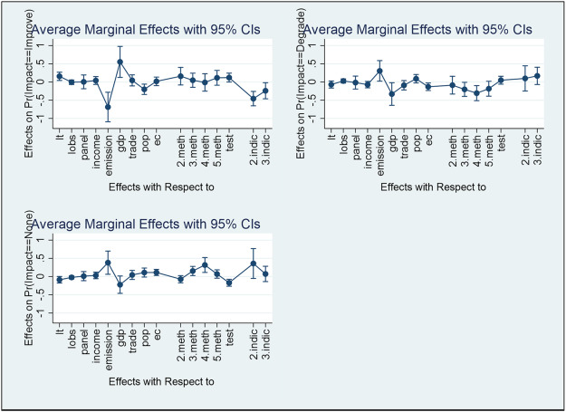

Fig. 5. Fitted plot of the estimated model for all categories

### 4.4. Test of independence of irrelevant alternatives

Hausman and McFadden (1984) test has been used verify the assumption which claims that the odds outcome–*J* vs outcome–*K* are independent of each other. Meaning that including or excluding any outcome leaves the other alternatives unaffected (Greene, 2003). To investigate the validity, we have computed *J – 1* test by omitting the remaining categories (improve and degrade) one by one. The results reported in Table 4 illustrates that *p*-values insignificant and we accept null hypothesis of IIA. It means that all alternatives of dependent variable are independent of each other and the inclusion or exclusion of either alternative leaves the rest two unaffected. The results so far presented and interpreted are parallel in one line with each other. This computation of wide variety of robustness tests make the results more reliable and accurate for policy implication.

Table 4. Hausman and McFadden test estimates.

| Omitted | Chi<sup>2</sup> | df | Prob ˃ Chi<sup>2</sup> |
| --- | --- | --- | --- |
| Improve | 0.88 | 8 | 0.998 |
| Degrade | 2.14 | 14 | 0.999 |

## 5. Conclusion and policy implications

Keeping in view the extensive work done for the empirical validation of EKC, we have investigated the literature in depth by using advanced quantitative tools. For the first time this study used a comprehensive data set comprised of 101 published research articles with 504 observations and employing MNL regression to estimate the parameters. The major contribution of the study is twofold: first, it develops a new framework PRIMRA, which is an extension to PRISMA framework developed by Moher et al. (2009). PRIMRA is anticipated to provide useful guidelines for future researches and meta-analysis; second, it clarifies the ambiguity regarding the existence of EKC. The results of this study are more robust because of employing various significance and robustness tests and can be adapted for future research.

The most important finding of this study is the validation of EKC, that is irrelevant to using any data set, control variable, and choice of econometric technique. It can be deduced that economic growth will first lead to deteriorate the quality of environment but beyond ITP it will improve its quality. Although achievement of the desired level of income is only possible in the long run, but not in the short run. On the other hand, uneven increase in population is coupled with excessive resource utilization and pollution increase. Results of this study acknowledged the negative impact of population increase on environmental quality. In the same way energy utilization is also harmful as it leads toxic emission and environmental degradation. Unlike the empirical literature, we have observed that choice of econometric methodology has no significant role in determining either type of relationship. Anyhow the MG/PMG estimation tool appeared significant throughout estimation. The most important issue highlighted in empirical literature is how to measure the environmental pollution. Different types of indicators have been used in literature. We have found that results are sensitive to the choice of environmental pollution indicators. The anthropogenic related measurements are more likely to support the existence of EKC while the chemical and biological indicators decrease the existence of this relationship.

The results of this study are more reliable because of the utilization of pre- and post-estimation robustness tests. First, the model has been selected using the LR test which indicated the use of restricted model instead of unrestricted. The estimated coefficients are interpreted in three ways; odd-ratios, RRR and average MEs. To greater extent, the results remained the same and have been confirmed by using Wald test for individual significance of coefficients. Furthermore, the most important assumption of MNL regression, IIA has also been validated by using Hausman and McFadden Test that increases the reliability of results.

As far as the policy implications of this study are concerned, it argues that achieving the ITP is a long run phenomenon so there is an immense need of long term regional and global level policy making. We have found that energy consumption has always contributed negatively to climate, so there is a dire need of adopting policies which encourage the use of carbon efficient technologies and reduce emission. On the other hand, the existing capacity of the earth should also be improved by increasing the forest cover. At the end, the researchers can benefit from the findings of this study not only adopting the new framework developed but also main reasons responsible for climate damage. In many cases the quantitative analyses are preferred over qualitative analyses. Researchers can rely more upon the findings of this study as it follows proper econometric procedure.

Based upon our results it can be deduced that environmental quality will improve once all nations finish the process of development in the long run. But the questions arise that is it possible for the whole world to develop and achieve the ITPs? if yes, then why there are climate emergencies? Why the world is too much conscious about climate change and its drastic impacts? Is there any problem with the process of development or the economies are converging very slow? Are the available resources of nature enough to survive till the world reaches to ITP? This dilemma give birth to new phase of research which need to be investigated in order to minimize the damage of development at the cost of environment. On the other hand, an indicator of environmental degradation is needed to be adopted which is more comprehensive. Sarkodie and Strezov (2019) have also shown their concern about selecting carefully the environmental indicator. Similarly, EKC hypothesis should be investigated by employing second generation estimation tools which are robust to various econometric problems. Also, the bibliometric method employed by Sarkodie and Strezov (2019) are also favored for future researches to best visualize the literature. Finally, energy consumption has always been negatively contributing to the environment and switch from fossil to renewable energy is needed. Although, this switch is not an easy task and will negatively affect GDP growth. So future research should be focused to investigate that how renewable energy can help to mitigate climate change without affecting growth. Keeping in view the net zero carbon emission scenario of Paris agreement until 2050, the next part of this study focuses on finding whether this objective can be achieved or not?

## Declaration of Competing Interest

The authors declare that they have no known competing financial interests or personal relationships that could have appeared to influence the work reported in this paper.

## Acknowledgment

The authors are grateful to Benoit Mulkay, Director Montpellier Research in Economics, and Adrien Nguyen-Huu, Center for Environmental Economics Montpellier, for their assistance in formulating methodology of this study. The valuable comments and suggestions of Antoine Pietri, Jimmy Martinez and Houda Hafidi were helpful in improving the quality of the study.

## Appendix A. Supplementary data

[Download : Download Word document (60KB)](https://ars.els-cdn.com/content/image/1-s2.0-S0195925520307812-mmc1.docx)

Supplementary material

## References

**Acar et al., 2018**

Y. Acar, T. Gürdal, Ş. Ekeryılmaz**Environmental Kuznets curve for CO2 emissions: an analysis for developing, Middle East, OECD and OPEC countries**

Environ. Socio-economic Studies, 6 (4) (2018), pp. 48-58, 10.2478/environ-2018-0027

[CrossRef](https://doi.org/10.2478/environ-2018-0027)[View Record in Scopus](https://www.scopus.com/inward/record.url?eid=2-s2.0-85059555878&partnerID=10&rel=R3.0.0)Google Scholar

**Ahmed and Long, 2012**

K. Ahmed, W. Long**Environmental Kuznets curve and Pakistan: an empirical analysis**

Proc. Econ. Fin., 1 (2012), pp. 4-13, 10.1016/S2212-5671(12)00003-2

[Article](https://www.sciencedirect.com/science/article/pii/S2212567112000032)[Download PDF](https://www.sciencedirect.com/science/article/pii/S2212567112000032/pdf?md5=622e02a6d349551ebd6f8efcbafdd4a3&pid=1-s2.0-S2212567112000032-main.pdf)[View Record in Scopus](https://www.scopus.com/inward/record.url?eid=2-s2.0-84871730370&partnerID=10&rel=R3.0.0)[Google Scholar](https://scholar.google.com/scholar_lookup?title=Environmental%20Kuznets%20curve%20and%20Pakistan%3A%20an%20empirical%20analysis&publication_year=2012&author=K.%20Ahmed&author=W.%20Long)

**Ali et al., 2017**

W. Ali, A. Abdullah, M. Azam**Re-visiting the environmental Kuznets curve hypothesis for Malaysia: fresh evidence from ARDL bounds testing approach**

Renew. Sust. Energ. Rev., 77 (2017), pp. 990-1000, 10.1016/j.rser.2016.11.236

[Article](https://www.sciencedirect.com/science/article/pii/S1364032116310127)[Download PDF](https://www.sciencedirect.com/science/article/pii/S1364032116310127/pdfft?md5=6bb358e33dbb90c9eda5eb1b17385ea6&pid=1-s2.0-S1364032116310127-main.pdf)[View Record in Scopus](https://www.scopus.com/inward/record.url?eid=2-s2.0-85007545155&partnerID=10&rel=R3.0.0)Google Scholar

**Al-Mulali et al., 2016**

U. Al-Mulali, I. Ozturk, S.A. Solarin**Investigating the environmental Kuznets curve hypothesis in seven regions: the role of renewable energy**

Ecol. Indic., 67 (2016), pp. 267-282, 10.1016/j.ecolind.2016.02.059

[Article](https://www.sciencedirect.com/science/article/pii/S1470160X16300802)[Download PDF](https://www.sciencedirect.com/science/article/pii/S1470160X16300802/pdfft?md5=49b604ead33b7a46985a4ece10ee442f&pid=1-s2.0-S1470160X16300802-main.pdf)[View Record in Scopus](https://www.scopus.com/inward/record.url?eid=2-s2.0-84960428038&partnerID=10&rel=R3.0.0)Google Scholar

**Apergis and Ozturk, 2015**

N. Apergis, I. Ozturk**Testing environmental Kuznets curve hypothesis in Asian countries**

Ecol. Indic., 52 (2015), pp. 16-22, 10.1016/j.ecolind.2014.11.026

[Article](https://www.sciencedirect.com/science/article/pii/S1470160X14005615)[Download PDF](https://www.sciencedirect.com/science/article/pii/S1470160X14005615/pdfft?md5=e37ed0a5a8c2b6bdf7b51d6956460be3&pid=1-s2.0-S1470160X14005615-main.pdf)[View Record in Scopus](https://www.scopus.com/inward/record.url?eid=2-s2.0-84919722754&partnerID=10&rel=R3.0.0)[Google Scholar](https://scholar.google.com/scholar_lookup?title=Testing%20environmental%20Kuznets%20curve%20hypothesis%20in%20Asian%20countries&publication_year=2015&author=N.%20Apergis&author=I.%20Ozturk)

**Armeanu et al., 2018**

D. Armeanu, G. Vintilă, J.V. Andrei, Ş.C. Gherghina, M.C. Drăgoi, C. Teodor**Exploring the link between environmental pollution and economic growth in EU-28 countries: is there an environmental Kuznets curve?**

PLoS One, 13 (5) (2018), 10.1371/journal.pone.0195708

[Google Scholar](https://scholar.google.com/scholar?q=Exploring%20the%20link%20between%20environmental%20pollution%20and%20economic%20growth%20in%20EU-28%20countries:%20is%20there%20an%20environmental%20Kuznets%20curve)

**Baležentis et al., 2019**

T. Baležentis, D. Streimikiene, T. Zhang, G. Liobikiene**The role of bioenergy in greenhouse gas emission reduction in EU countries: an environmental Kuznets curve modelling**

Resour. Conserv. Recycl., 142 (2019), pp. 225-231, 10.1016/j.resconrec.2018.12.019

[Article](https://www.sciencedirect.com/science/article/pii/S0921344918304750)[Download PDF](https://www.sciencedirect.com/science/article/pii/S0921344918304750/pdfft?md5=37b0988a6907d0b961b05ed2360a04cb&pid=1-s2.0-S0921344918304750-main.pdf)[View Record in Scopus](https://www.scopus.com/inward/record.url?eid=2-s2.0-85058456181&partnerID=10&rel=R3.0.0)Google Scholar

**Begum et al., 2015**

R.A. Begum, K. Sohag, S.M.S. Abdullah, M. Jaafar**CO2 emissions, energy consumption, economic and population growth in Malaysia**

Renew. Sust. Energ. Rev., 41 (2015), pp. 594-601, 10.1016/j.rser.2014.07.205

[Article](https://www.sciencedirect.com/science/article/pii/S1364032114006650)[Download PDF](https://www.sciencedirect.com/science/article/pii/S1364032114006650/pdfft?md5=7c717ab4cbf4a5df4b6074c5c4db47b7&pid=1-s2.0-S1364032114006650-main.pdf)[View Record in Scopus](https://www.scopus.com/inward/record.url?eid=2-s2.0-84907530108&partnerID=10&rel=R3.0.0)Google Scholar

**Bilgili et al., 2016**

F. Bilgili, E. Koçak, Ü. Bulut**The dynamic impact of renewable energy consumption on CO2 emissions: a revisited environmental Kuznets curve approach**

Renew. Sust. Energ. Rev., 54 (2016), pp. 838-845, 10.1016/j.rser.2015.10.080

[Article](https://www.sciencedirect.com/science/article/pii/S1364032115011594)[Download PDF](https://www.sciencedirect.com/science/article/pii/S1364032115011594/pdfft?md5=7d05f1d50e41d5e7502935d8c1d32f3d&pid=1-s2.0-S1364032115011594-main.pdf)[View Record in Scopus](https://www.scopus.com/inward/record.url?eid=2-s2.0-84946606196&partnerID=10&rel=R3.0.0)Google Scholar

**Cavlovic et al., 2000**

T.A. Cavlovic, K.H. Baker, R.P. Berrens, K. Gawande**A meta-analysis of environmental Kuznets curve studies**

Agricult. Res. Econ. Rev., 29 (1) (2000), pp. 32-42, 10.1017/S1068280500001416

[View Record in Scopus](https://www.scopus.com/inward/record.url?eid=2-s2.0-0002215716&partnerID=10&rel=R3.0.0)Google Scholar

**Cheng and Long, 2007**

S. Cheng, J.S. Long**Testing for IIA in the multinomial logit model**

Sociol. Methods Res., 35 (4) (2007), pp. 583-600

doi:10.1177%2F0049124106292361

[CrossRef](https://doi.org/10.1177/0049124106292361)[View Record in Scopus](https://www.scopus.com/inward/record.url?eid=2-s2.0-34247105916&partnerID=10&rel=R3.0.0)[Google Scholar](https://scholar.google.com/scholar_lookup?title=Testing%20for%20IIA%20in%20the%20multinomial%20logit%20model&publication_year=2007&author=S.%20Cheng&author=J.S.%20Long)

**Churchill et al., 2018**

S.A. Churchill, J. Inekwe, K. Ivanovski, R. Smyth**The environmental Kuznets curve in the OECD: 1870–2014**

Energy Economics, 75 (2018), pp. 389-399, 10.1016/j.enpol.2013.10.064

[View Record in Scopus](https://www.scopus.com/inward/record.url?eid=2-s2.0-85053442890&partnerID=10&rel=R3.0.0)[Google Scholar](https://scholar.google.com/scholar?q=The%20environmental%20Kuznets%20curve%20in%20the%20OECD:%2018702014)

**Destek and Sarkodie, 2019**

M.A. Destek, S.A. Sarkodie**Investigation of environmental Kuznets curve for ecological footprint: the role of energy and financial development**

Sci. Total Environ., 650 (2019), pp. 2483-2489, 10.1016/j.scitotenv.2018.10.017

[Article](https://www.sciencedirect.com/science/article/pii/S0048969718338907)[Download PDF](https://www.sciencedirect.com/science/article/pii/S0048969718338907/pdfft?md5=5d437394b678ab947f0d2c67bfcfc3c5&pid=1-s2.0-S0048969718338907-main.pdf)[View Record in Scopus](https://www.scopus.com/inward/record.url?eid=2-s2.0-85054301802&partnerID=10&rel=R3.0.0)Google Scholar

**Dinda and Coondoo, 2006**

S. Dinda, D. Coondoo**Income and emission: a panel data-based cointegration analysis**

Ecol. Econ., 57 (2) (2006), pp. 167-181, 10.1016/j.ecolecon.2005.03.028

[Article](https://www.sciencedirect.com/science/article/pii/S0921800905001692)[Download PDF](https://www.sciencedirect.com/science/article/pii/S0921800905001692/pdfft?md5=4f2653b72eca991bb78953cebb8e6fe4&pid=1-s2.0-S0921800905001692-main.pdf)[View Record in Scopus](https://www.scopus.com/inward/record.url?eid=2-s2.0-33646471406&partnerID=10&rel=R3.0.0)[Google Scholar](https://scholar.google.com/scholar_lookup?title=Income%20and%20emission%3A%20a%20panel%20data-based%20cointegration%20analysis&publication_year=2006&author=S.%20Dinda&author=D.%20Coondoo)

**Dogan and Turkekul, 2016**

E. Dogan, B. Turkekul**CO<sub>2</sub> emissions, real output, energy consumption, trade, urbanization and financial development: testing the EKC hypothesis for the USA**

Environ. Sci. Pollut. Res., 23 (2) (2016), pp. 1203-1213, 10.1007/s11356-015-5323-8

[CrossRef](https://doi.org/10.1007/s11356-015-5323-8)[View Record in Scopus](https://www.scopus.com/inward/record.url?eid=2-s2.0-84954387996&partnerID=10&rel=R3.0.0)Google Scholar

**Dong et al., 2018**

K. Dong, R. Sun, H. Jiang, X. Zeng**CO2 emissions, economic growth, and the environmental Kuznets curve in China: what roles can nuclear energy and renewable energy play?**

J. Clean. Prod., 196 (2018), pp. 51-63, 10.1016/j.jclepro.2018.05.271

[Article](https://www.sciencedirect.com/science/article/pii/S095965261831624X)[Download PDF](https://www.sciencedirect.com/science/article/pii/S095965261831624X/pdfft?md5=f42ca11139ea69401698f78da423f3f6&pid=1-s2.0-S095965261831624X-main.pdf)[View Record in Scopus](https://www.scopus.com/inward/record.url?eid=2-s2.0-85049340403&partnerID=10&rel=R3.0.0)[Google Scholar](https://scholar.google.com/scholar?q=CO2%20emissions,%20economic%20growth,%20and%20the%20environmental%20Kuznets%20curve%20in%20China:%20what%20roles%20can%20nuclear%20energy%20and%20renewable%20energy%20play)

**Farhani et al., 2014**

S. Farhani, S. Mrizak, A. Chaibi, C. Rault**The environmental Kuznets curve and sustainability: a panel data analysis**

Energy Policy, 71 (2014), pp. 189-198, 10.1016/j.enpol.2014.04.030

[Article](https://www.sciencedirect.com/science/article/pii/S0301421514002651)[Download PDF](https://www.sciencedirect.com/science/article/pii/S0301421514002651/pdfft?md5=d9e6b4513f26eed997741a2b817230f6&pid=1-s2.0-S0301421514002651-main.pdf)[View Record in Scopus](https://www.scopus.com/inward/record.url?eid=2-s2.0-84902119273&partnerID=10&rel=R3.0.0)Google Scholar

**Greene, 2003**

W.H. Greene**Econometric Analysis**

Pearson Education India (2003)

[Google Scholar](https://scholar.google.com/scholar_lookup?title=Econometric%20Analysis&publication_year=2003&author=W.H.%20Greene)

**Grossman and Krueger, 1991**

G.M. Grossman, A.B. Krueger

National Bureau of Economic Research (Ed.), Environmental Impacts of a North American Free Trade Agreement (No. w3914) (1991), 10.3386/w3914

[Google Scholar](https://scholar.google.com/scholar?q=Environmental%20Impacts%20of%20a%20North%20American%20Free%20Trade%20Agreement)

**Grossman and Krueger, 1995**

G.M. Grossman, A.B. Krueger**Economic growth and the environment**

Q. J. Econ., 110 (2) (1995), pp. 353-377, 10.2307/2118443

[CrossRef](https://doi.org/10.2307/2118443)[View Record in Scopus](https://www.scopus.com/inward/record.url?eid=2-s2.0-0029505672&partnerID=10&rel=R3.0.0)[Google Scholar](https://scholar.google.com/scholar_lookup?title=Economic%20growth%20and%20the%20environment&publication_year=1995&author=G.M.%20Grossman&author=A.B.%20Krueger)

**Hao et al., 2018**

Y. Hao, Y. Wu, L. Wang, J. Huang**Re-examine environmental Kuznets curve in China: Spatial estimations using environmental quality index**

Sustainable Cities and Society, 42 (2018), pp. 498-511, 10.1016/j.scs.2018.08.014

[Article](https://www.sciencedirect.com/science/article/pii/S2210670718306449)[Download PDF](https://www.sciencedirect.com/science/article/pii/S2210670718306449/pdfft?md5=0d4d098e6c521df2a3a1db7ed18d7a04&pid=1-s2.0-S2210670718306449-main.pdf)[View Record in Scopus](https://www.scopus.com/inward/record.url?eid=2-s2.0-85051665620&partnerID=10&rel=R3.0.0)Google Scholar

**Harbaugh et al., 2002**

W.T. Harbaugh, A. Levinson, D.M. Wilson**Reexamining the empirical evidence for an environmental Kuznets curve**

Rev. Econ. Stat., 84 (3) (2002), pp. 541-551, 10.1162/003465302320259538

[View Record in Scopus](https://www.scopus.com/inward/record.url?eid=2-s2.0-0036330795&partnerID=10&rel=R3.0.0)Google Scholar

**Hausman and McFadden, 1984**

J. Hausman, D. McFadden**Specification tests for the multinomial logit model**

Econometrica. (1984), pp. 1219-1240, 10.2307/1910997

[CrossRef](https://doi.org/10.2307/1910997)[View Record in Scopus](https://www.scopus.com/inward/record.url?eid=2-s2.0-0021575963&partnerID=10&rel=R3.0.0)[Google Scholar](https://scholar.google.com/scholar_lookup?title=Specification%20tests%20for%20the%20multinomial%20logit%20model&publication_year=1984&author=J.%20Hausman&author=D.%20McFadden)

**Hosmer Jr et al., 2013**

D.W. Hosmer Jr., S. Lemeshow, R.X. Sturdivant**Applied Logistic Regression**

Vol. 398, John Wiley & Sons (2013)

ISBN: 978-0-470-58247-3

[Google Scholar](https://scholar.google.com/scholar_lookup?title=Applied%20Logistic%20Regression&publication_year=2013&author=D.W.%20Hosmer%20Jr.&author=S.%20Lemeshow&author=R.X.%20Sturdivant)

**Işık et al., 2019**

C. Işık, S. Ongan, D. Özdemir**Testing the EKC hypothesis for ten US states: an application of heterogeneous panel estimation method**

Environ. Sci. Pollut. Res., 26 (11) (2019), pp. 10846-10853, 10.1007/s11356-019-04514-6

[CrossRef](https://doi.org/10.1007/s11356-019-04514-6)[View Record in Scopus](https://www.scopus.com/inward/record.url?eid=2-s2.0-85061735629&partnerID=10&rel=R3.0.0)Google Scholar

**Jebli and Youssef, 2015**

M.B. Jebli, S.B. Youssef**The environmental Kuznets curve, economic growth, renewable and non-renewable energy, and trade in Tunisia**

Renew. Sust. Energ. Rev., 47 (2015), pp. 173-185, 10.1016/j.rser.2015.02.049

Google Scholar

**Khan et al., 2019**

I. Khan, M. Saqib, H. Hafidi**Poverty and environmental nexus in rural Pakistan: a multidimensional approach**

GeoJournal (2019), pp. 1-15, 10.1007/s10708-019-10090-6

[View Record in Scopus](https://www.scopus.com/inward/record.url?eid=2-s2.0-85083513002&partnerID=10&rel=R3.0.0)Google Scholar

**Lau et al., 2019**

L.S. Lau, C.K. Choong, C.F. Ng, F.M. Liew, S.L. Ching**Is nuclear energy clean? Revisit of environmental Kuznets curve hypothesis in OECD countries**

Econ. Model., 77 (2019), pp. 12-20, 10.1016/j.econmod.2018.09.015

[Article](https://www.sciencedirect.com/science/article/pii/S0264999318302761)[Download PDF](https://www.sciencedirect.com/science/article/pii/S0264999318302761/pdfft?md5=0a49d0a5bd3a467cd36e8f3d0c46a6d9&pid=1-s2.0-S0264999318302761-main.pdf)[View Record in Scopus](https://www.scopus.com/inward/record.url?eid=2-s2.0-85064227180&partnerID=10&rel=R3.0.0)[Google Scholar](https://scholar.google.com/scholar?q=Is%20nuclear%20energy%20clean%20Revisit%20of%20environmental%20Kuznets%20curve%20hypothesis%20in%20OECD%20countries)

**Li et al., 2007**

H. Li, T. Grijalva, R.P. Berrens**Economic growth and environmental quality: a meta-analysis of environmental Kuznets curve studies**

Econ. Bull., 17 (5) (2007), pp. 1-11

http://economicsbulletin.vanderbilt.edu/2007/volume17/EB-06Q20005A.pdf

[CrossRef](https://doi.org/10.1145/1577222.1577229)[View Record in Scopus](https://www.scopus.com/inward/record.url?eid=2-s2.0-71149091510&partnerID=10&rel=R3.0.0)Google Scholar

**Li et al., 2016**

T. Li, Y. Wang, D. Zhao**Environmental Kuznets curve in China: new evidence from dynamic panel analysis**

Energy Policy, 91 (2016), pp. 138-147, 10.1016/j.enpol.2016.01.002

[Article](https://www.sciencedirect.com/science/article/pii/S0301421516300027)[Download PDF](https://www.sciencedirect.com/science/article/pii/S0301421516300027/pdfft?md5=d936377e8c8621f4c995d8b2d41ad5e6&pid=1-s2.0-S0301421516300027-main.pdf)[View Record in Scopus](https://www.scopus.com/inward/record.url?eid=2-s2.0-84958232181&partnerID=10&rel=R3.0.0)Google Scholar

**Liu et al., 2017**

X. Liu, S. Zhang, J. Bae**The impact of renewable energy and agriculture on carbon dioxide emissions: investigating the environmental Kuznets curve in four selected ASEAN countries**

J. Clean. Prod., 164 (2017), pp. 1239-1247, 10.1016/j.jclepro.2017.07.086

[Article](https://www.sciencedirect.com/science/article/pii/S0959652617315147)[Download PDF](https://www.sciencedirect.com/science/article/pii/S0959652617315147/pdfft?md5=00992d9064bbb93f02348acf75cbc680&pid=1-s2.0-S0959652617315147-main.pdf)[View Record in Scopus](https://www.scopus.com/inward/record.url?eid=2-s2.0-85025653290&partnerID=10&rel=R3.0.0)Google Scholar

**Liu et al., 2019**

J. Liu, J. Qu, K. Zhao**Is China’s development confirming to the environmental Kuznets curve hypothesis and the pollution haven hypothesis?**

J. Clean. Prod., 234 (2019), pp. 787-796, 10.1016/j.jclepro.2019.06.234

[Article](https://www.sciencedirect.com/science/article/pii/S0959652619321997)[Download PDF](https://www.sciencedirect.com/science/article/pii/S0959652619321997/pdfft?md5=d09f771a7299c3d70413c5082dcf60d8&pid=1-s2.0-S0959652619321997-main.pdf)[View Record in Scopus](https://www.scopus.com/inward/record.url?eid=2-s2.0-85068044760&partnerID=10&rel=R3.0.0)[Google Scholar](https://scholar.google.com/scholar?q=Is%20Chinas%20development%20confirming%20to%20the%20environmental%20Kuznets%20curve%20hypothesis%20and%20the%20pollution%20haven%20hypothesis)

**Long and Freese, 2001**

J.S. Long, J. Freese**Regression Models for Categorical Dependent Variables Using Stata**

(2nd edition), Stata Press (2001)

[Google Scholar](https://scholar.google.com/scholar_lookup?title=Regression%20Models%20for%20Categorical%20Dependent%20Variables%20Using%20Stata&publication_year=2001&author=J.S.%20Long&author=J.%20Freese)

**Moher et al., 2009**

D. Moher, A. Liberati, J. Tetzlaff, D.G. Altman**Preferred reporting items for systematic reviews and meta-analyses: the PRISMA statement**

Ann. Intern. Med., 151 (4) (2009), pp. 264-269, 10.7326/0003-4819-151-4-200908180-00135

[CrossRef](https://doi.org/10.7326/0003-4819-151-4-200908180-00135)[View Record in Scopus](https://www.scopus.com/inward/record.url?eid=2-s2.0-69149107165&partnerID=10&rel=R3.0.0)Google Scholar

**Moutinho et al., 2017**

V. Moutinho, C. Varum, M. Madaleno**How economic growth affects emissions? An investigation of the environmental Kuznets curve in Portuguese and Spanish economic activity sectors**

Energy Policy, 106 (2017), pp. 326-344, 10.1016/j.enpol.2017.03.069

[Article](https://www.sciencedirect.com/science/article/pii/S0301421517302252)[Download PDF](https://www.sciencedirect.com/science/article/pii/S0301421517302252/pdfft?md5=fb102232ea636a92aa225b20f9162cad&pid=1-s2.0-S0301421517302252-main.pdf)[View Record in Scopus](https://www.scopus.com/inward/record.url?eid=2-s2.0-85017099219&partnerID=10&rel=R3.0.0)Google Scholar

**Mrabet and Alsamara, 2017**

Z. Mrabet, M. Alsamara**Testing the Kuznets curve hypothesis for Qatar: a comparison between carbon dioxide and ecological footprint**

Renew. Sust. Energ. Rev., 70 (2017), pp. 1366-1375, 10.1016/j.rser.2016.12.039

[Article](https://www.sciencedirect.com/science/article/pii/S1364032116310929)[Download PDF](https://www.sciencedirect.com/science/article/pii/S1364032116310929/pdfft?md5=2b059847053a7bafe94a89fa5cbf834a&pid=1-s2.0-S1364032116310929-main.pdf)[View Record in Scopus](https://www.scopus.com/inward/record.url?eid=2-s2.0-85008440082&partnerID=10&rel=R3.0.0)Google Scholar

**Nasir et al., 2019**

M.A. Nasir, T.L.D. Huynh, H.T.X. Tram**Role of financial development, economic growth & foreign direct investment in driving climate change: a case of emerging ASEAN**

J. Environ. Manag., 242 (2019), pp. 131-141, 10.1016/j.jenvman.2019.03.112

[Article](https://www.sciencedirect.com/science/article/pii/S0301479719304256)[Download PDF](https://www.sciencedirect.com/science/article/pii/S0301479719304256/pdfft?md5=6916fffe55c1c756de92c4c1c976b697&pid=1-s2.0-S0301479719304256-main.pdf)[View Record in Scopus](https://www.scopus.com/inward/record.url?eid=2-s2.0-85065795934&partnerID=10&rel=R3.0.0)[Google Scholar](https://scholar.google.com/scholar?q=Role%20of%20financial%20development,%20economic%20growth%20%20foreign%20direct%20investment%20in%20driving%20climate%20change:%20a%20case%20of%20emerging%20ASEAN)

**Norton et al., 2019**

E.C. Norton, B.E. Dowd, M.L. Maciejewski**Marginal effects quantifying the effect of changes in risk factors in logistic regression models**

JAMA., 321 (13) (2019), pp. 1304-1305

http://doi:10.1001/jama.2019.1954

[CrossRef](https://doi.org/10.1001/jama.2019.1954)[View Record in Scopus](https://www.scopus.com/inward/record.url?eid=2-s2.0-85062723138&partnerID=10&rel=R3.0.0)Google Scholar

**Panayotou, 1993**

T. Panayotou**Empirical tests and policy analysis of environmental degradation at different stages of economic development (No. 992927783402676)**

International Labour Organization (1993)

[Google Scholar](https://scholar.google.com/scholar?q=Empirical%20tests%20and%20policy%20analysis%20of%20environmental%20degradation%20at%20different%20stages%20of%20economic%20development)

**Pao et al., 2011**

H.T. Pao, H.C. Yu, Y.H. Yang**Modeling the CO2 emissions, energy use, and economic growth in Russia**

Energy, 36 (8) (2011), pp. 5094-5100, 10.1016/j.energy.2011.06.004

[Article](https://www.sciencedirect.com/science/article/pii/S0360544211003811)[Download PDF](https://www.sciencedirect.com/science/article/pii/S0360544211003811/pdfft?md5=a8d095ab82dc2a9a3e2341cf0fd97b18&pid=1-s2.0-S0360544211003811-main.pdf)[View Record in Scopus](https://www.scopus.com/inward/record.url?eid=2-s2.0-79961023140&partnerID=10&rel=R3.0.0)Google Scholar

**Pata, 2018**

U.K. Pata**Renewable energy consumption, urbanization, financial development, income and CO2 emissions in Turkey: testing EKC hypothesis with structural breaks**

J. Clean. Prod., 187 (2018), pp. 770-779, 10.1016/j.jclepro.2018.03.236

[Article](https://www.sciencedirect.com/science/article/pii/S0959652618309132)[Download PDF](https://www.sciencedirect.com/science/article/pii/S0959652618309132/pdfft?md5=ccbd0d2827bd6b82faf256bdf5fe547c&pid=1-s2.0-S0959652618309132-main.pdf)[View Record in Scopus](https://www.scopus.com/inward/record.url?eid=2-s2.0-85047649329&partnerID=10&rel=R3.0.0)Google Scholar

**Pham et al., 2020**

N.M. Pham, T.L.D. Huynh, M.A. Nasir**Environmental consequences of population, affluence and technological progress for European countries: a Malthusian view**

J. Environ. Manag., 260 (2020), Article 110143, 10.1016/j.jenvman.2020.110143

[Article](https://www.sciencedirect.com/science/article/pii/S0301479720300803)[Download PDF](https://www.sciencedirect.com/science/article/pii/S0301479720300803/pdfft?md5=4f14125b4b48aadbe4f03a925781e6a1&pid=1-s2.0-S0301479720300803-main.pdf)Google Scholar

**Ridzuan, 2019**

S. Ridzuan**Inequality and the environmental Kuznets curve**

J. Clean. Prod., 228 (2019), pp. 1472-1481, 10.1016/j.jclepro.2019.04.284

[Article](https://www.sciencedirect.com/science/article/pii/S0959652619313757)[Download PDF](https://www.sciencedirect.com/science/article/pii/S0959652619313757/pdfft?md5=bb7bbcae2b3713948cc4a268310ed748&pid=1-s2.0-S0959652619313757-main.pdf)[View Record in Scopus](https://www.scopus.com/inward/record.url?eid=2-s2.0-85065485452&partnerID=10&rel=R3.0.0)[Google Scholar](https://scholar.google.com/scholar_lookup?title=Inequality%20and%20the%20environmental%20Kuznets%20curve&publication_year=2019&author=S.%20Ridzuan)

**Shafiei and Salim, 2014**

S. Shafiei, R.A. Salim**Non-renewable and renewable energy consumption and CO2 emissions in OECD countries: A comparative analysis**

Energy Policy, 66 (2014), pp. 547-556, 10.1016/j.enpol.2013.10.064

[Article](https://www.sciencedirect.com/science/article/pii/S0301421513010872)[Download PDF](https://www.sciencedirect.com/science/article/pii/S0301421513010872/pdfft?md5=c25fe9f16baa39f3e4300f97bd6fcd6d&pid=1-s2.0-S0301421513010872-main.pdf)[View Record in Scopus](https://www.scopus.com/inward/record.url?eid=2-s2.0-84892451289&partnerID=10&rel=R3.0.0)Google Scholar

**Sarkodie and Strezov, 2018**

S.A. Sarkodie, V. Strezov**Empirical study of the environmental Kuznets curve and environmental sustainability curve hypothesis for Australia, China, Ghana and USA**

J. Clean. Prod., 201 (2018), pp. 98-110, 10.1016/j.jclepro.2018.08.039

[Article](https://www.sciencedirect.com/science/article/pii/S0959652618323722)[Download PDF](https://www.sciencedirect.com/science/article/pii/S0959652618323722/pdfft?md5=038c4af2fbcee5345a0488914a595f31&pid=1-s2.0-S0959652618323722-main.pdf)[View Record in Scopus](https://www.scopus.com/inward/record.url?eid=2-s2.0-85052474772&partnerID=10&rel=R3.0.0)Google Scholar

**Sarkodie and Strezov, 2019**

S.A. Sarkodie, V. Strezov**A review on environmental Kuznets curve hypothesis using bibliometric and meta-analysis**

Sci. Total Environ., 649 (2019), pp. 128-145, 10.1016/j.scitotenv.2018.08.276

[Article](https://www.sciencedirect.com/science/article/pii/S0048969718332480)[Download PDF](https://www.sciencedirect.com/science/article/pii/S0048969718332480/pdfft?md5=679c817f948f5274e7f9e1d0607b56ad&pid=1-s2.0-S0048969718332480-main.pdf)[View Record in Scopus](https://www.scopus.com/inward/record.url?eid=2-s2.0-85052450325&partnerID=10&rel=R3.0.0)Google Scholar

**Sebri, 2015**

M. Sebri**Use renewables to be cleaner: meta-analysis of the renewable energy consumption–economic growth nexus**

Renew. Sust. Energ. Rev., 42 (2015), pp. 657-665, 10.1016/j.rser.2014.10.042

[Article](https://www.sciencedirect.com/science/article/pii/S1364032114008673)[Download PDF](https://www.sciencedirect.com/science/article/pii/S1364032114008673/pdfft?md5=d532d978e1f4a677adc2bf9ab1c96da8&pid=1-s2.0-S1364032114008673-main.pdf)[View Record in Scopus](https://www.scopus.com/inward/record.url?eid=2-s2.0-84909947228&partnerID=10&rel=R3.0.0)[Google Scholar](https://scholar.google.com/scholar?q=Use%20renewables%20to%20be%20cleaner:%20meta-analysis%20of%20the%20renewable%20energy%20consumptioneconomic%20growth%20nexus)

**Selden and Song, 1994**

T.M. Selden, D. Song**Environmental quality and development:is there a Kuznets curve for air pollution emissions?**

J. Environ. Econ. Manag., 27 (2) (1994), pp. 147-162, 10.1006/jeem.1994.1031

[Article](https://www.sciencedirect.com/science/article/pii/S009506968471031X)[Download PDF](https://www.sciencedirect.com/science/article/pii/S009506968471031X/pdf?md5=4ba587d2aaf6c7b697882976d0b6cc7a&pid=1-s2.0-S009506968471031X-main.pdf)[View Record in Scopus](https://www.scopus.com/inward/record.url?eid=2-s2.0-0028156074&partnerID=10&rel=R3.0.0)[Google Scholar](https://scholar.google.com/scholar?q=Environmental%20quality%20and%20development:is%20there%20a%20Kuznets%20curve%20for%20air%20pollution%20emissions)

**Selden et al., 1999**

T.M. Selden, A.S. Forrest, J.E. Lockhart**Analyzing the reductions in US air pollution emissions: 1970 to 1990**

Land Econ. (1999), pp. 1-21

https://www.jstor.org/stable/3146990

[CrossRef](https://doi.org/10.2307/3146990)[View Record in Scopus](https://www.scopus.com/inward/record.url?eid=2-s2.0-0032807853&partnerID=10&rel=R3.0.0)Google Scholar

**Shahbaz et al., 2012**

M. Shahbaz, H.H. Lean, M.S. Shabbir**Environmental Kuznets curve hypothesis in Pakistan: cointegration and granger causality**

Renew. Sust. Energ. Rev., 16 (5) (2012), pp. 2947-2953, 10.1016/j.rser.2012.02.015

[Article](https://www.sciencedirect.com/science/article/pii/S1364032112001086)[Download PDF](https://www.sciencedirect.com/science/article/pii/S1364032112001086/pdfft?md5=d26e77f97ac09217ab75719cb90db011&pid=1-s2.0-S1364032112001086-main.pdf)[View Record in Scopus](https://www.scopus.com/inward/record.url?eid=2-s2.0-84858742327&partnerID=10&rel=R3.0.0)Google Scholar

**Song et al., 2008**

T. Song, T. Zheng, T. Lianjun**An empirical test of the environmental Kuznets curve in China: a panel cointegration approach**

China Econ. Rev., 19 (3) (2008), pp. 381-392, 10.1016/j.chieco.2007.10.001

[Article](https://www.sciencedirect.com/science/article/pii/S1043951X07000594)[Download PDF](https://www.sciencedirect.com/science/article/pii/S1043951X07000594/pdfft?md5=d3ba2f01842e565a9aebddf50dacca44&pid=1-s2.0-S1043951X07000594-main.pdf)[View Record in Scopus](https://www.scopus.com/inward/record.url?eid=2-s2.0-47949102182&partnerID=10&rel=R3.0.0)Google Scholar

**Stern, 2003**

D.I. Stern**International Society for Ecological Economics Internet Encyclopedia of Ecological Economics the Environmental Kuznets Curve**

Department of Economics, Rensselaer Polytechnic Institute (2003)

Google Scholar

**Stern, 2010**

D.I. Stern**Between estimates of the emissions-income elasticity**

Ecol. Econ., 69 (11) (2010), pp. 2173-2182, 10.1016/j.ecolecon.2010.06.024

[Article](https://www.sciencedirect.com/science/article/pii/S092180091000265X)[Download PDF](https://www.sciencedirect.com/science/article/pii/S092180091000265X/pdfft?md5=7295364ea80a7b52c5c6c736f1db6eaa&pid=1-s2.0-S092180091000265X-main.pdf)[View Record in Scopus](https://www.scopus.com/inward/record.url?eid=2-s2.0-77956192169&partnerID=10&rel=R3.0.0)[Google Scholar](https://scholar.google.com/scholar_lookup?title=Between%20estimates%20of%20the%20emissions-income%20elasticity&publication_year=2010&author=D.I.%20Stern)

**Tamazian et al., 2009**

A. Tamazian, J.P. Chousa, K.C. Vadlamannati**Does higher economic and financial development lead to environmental degradation: evidence from BRIC countries**

Energy Policy, 37 (1) (2009), pp. 246-253, 10.1016/j.enpol.2008.08.025

[Article](https://www.sciencedirect.com/science/article/pii/S0301421508005065)[Download PDF](https://www.sciencedirect.com/science/article/pii/S0301421508005065/pdfft?md5=48d18116cbe541e1a89bf24b6a97fd9b&pid=1-s2.0-S0301421508005065-main.pdf)[View Record in Scopus](https://www.scopus.com/inward/record.url?eid=2-s2.0-56949098618&partnerID=10&rel=R3.0.0)Google Scholar

**Thompson and Higgins, 2002**

S.G. Thompson, J.P. Higgins**How should meta-regression analyses be undertaken and interpreted?**

Stat. Med., 21 (11) (2002), pp. 1559-1573, 10.1002/sim.1187

[View Record in Scopus](https://www.scopus.com/inward/record.url?eid=2-s2.0-0037098178&partnerID=10&rel=R3.0.0)[Google Scholar](https://scholar.google.com/scholar?q=How%20should%20meta-regression%20analyses%20be%20undertaken%20and%20interpreted)

**Tiwari et al., 2013**

A.K. Tiwari, M. Shahbaz, Q.M.A. Hye**The environmental Kuznets curve and the role of coal consumption in India: cointegration and causality analysis in an open economy**

Renew. Sust. Energ. Rev., 18 (2013), pp. 519-527, 10.1016/j.rser.2012.10.031

[Article](https://www.sciencedirect.com/science/article/pii/S1364032112005734)[Download PDF](https://www.sciencedirect.com/science/article/pii/S1364032112005734/pdfft?md5=f40cffb2fe537ee1684fc15a1d2923ed&pid=1-s2.0-S1364032112005734-main.pdf)[View Record in Scopus](https://www.scopus.com/inward/record.url?eid=2-s2.0-84869862564&partnerID=10&rel=R3.0.0)Google Scholar

**Wagner, 2008**

M. Wagner**The carbon Kuznets curve: a cloudy picture emitted by bad econometrics?**

Resour. Energy Econ., 30 (3) (2008), pp. 388-408, 10.1016/j.reseneeco.2007.11.001

[Article](https://www.sciencedirect.com/science/article/pii/S0928765507000504)[Download PDF](https://www.sciencedirect.com/science/article/pii/S0928765507000504/pdfft?md5=1deb57e02624bdf9cfeb1334f50c092e&pid=1-s2.0-S0928765507000504-main.pdf)[View Record in Scopus](https://www.scopus.com/inward/record.url?eid=2-s2.0-44649192347&partnerID=10&rel=R3.0.0)[Google Scholar](https://scholar.google.com/scholar?q=The%20carbon%20Kuznets%20curve:%20a%20cloudy%20picture%20emitted%20by%20bad%20econometrics)

**Wang et al., 2019**

Z. Wang, C. Bu, H. Li, W. Wei**Seawater environmental Kuznets curve: evidence from seawater quality in China’s coastal waters**

J. Clean. Prod., 219 (2019), pp. 925-935, 10.1016/j.jclepro.2019.02.012

[Article](https://www.sciencedirect.com/science/article/pii/S0959652619303919)[Download PDF](https://www.sciencedirect.com/science/article/pii/S0959652619303919/pdfft?md5=1cc40f2b356839fa39266832ce46116d&pid=1-s2.0-S0959652619303919-main.pdf)[View Record in Scopus](https://www.scopus.com/inward/record.url?eid=2-s2.0-85062262742&partnerID=10&rel=R3.0.0)[Google Scholar](https://scholar.google.com/scholar?q=Seawater%20environmental%20Kuznets%20curve:%20evidence%20from%20seawater%20quality%20in%20Chinas%20coastal%20waters)

**Zambrano-Monserrate et al., 2018**

M.A. Zambrano-Monserrate, C.A. Silva-Zambrano, J.L. Davalos-Penafiel, A. Zambrano-Monserrate, M.A. Ruano**Testing EKC hypothesis in Peru: the role of renewable electricity, petroleum and dry natural gas**

Renew. Sust. Energ. Rev., 82 (2018), pp. 4170-4178, 10.1016/j.rser.2017.11.005

[Article](https://www.sciencedirect.com/science/article/pii/S1364032117315319)[Download PDF](https://www.sciencedirect.com/science/article/pii/S1364032117315319/pdfft?md5=a8c7704e58ade1fd9a78e44b76dbc043&pid=1-s2.0-S1364032117315319-main.pdf)[View Record in Scopus](https://www.scopus.com/inward/record.url?eid=2-s2.0-85038821043&partnerID=10&rel=R3.0.0)Google Scholar

**<sup>1</sup>**

The logistic regression results for this model are reported in Table 3 in supplementary materials.

**<sup>2</sup>**

Coefficients for some variables presented in Table 1 are not reported and dropped in the light of LR-test.

[View Abstract](https://www.sciencedirect.com/science/article/abs/pii/S0195925520307812)

© 2020 Elsevier Inc. All rights reserved.